# Stats 102A - Homework 2

Yaqiong Liu

Fall 2017

*Modify this file with your answers and responses. Please preserve all text that is italicized.*

### Reading

1. Scientific Programming and Simulation Using R (SPURS) - Chapters 3 and 5
2. Advanced R - Chapter 6 sections 1 through 4
1. *SPURS chapter 3, section 9, exercise 1. [10pts]*  
   The function has derivative at x = 0, and the derivative is 0; at x = 1, however, the function doesn’t have derivative.

```r
f <- function(x){
  if(!is.numeric(x)) stop("X should be a number!")
  if(x<=0){
    return(-x^3)
  }else if(x>1){
    return(x^(1/2))
  }else{
    return(x^2)
  }
}
```

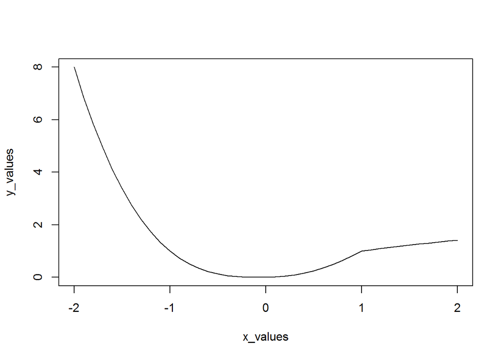

```r
# do not modify this code
x_values <- seq(-2, 2, by = 0.1)
y_values <- rep(NA, length(x_values))
for (i in seq_along(x_values)) {
  x <- x_values[i]
  y_values[i] <- f(x)
}

# output
plot(x_values, y_values, type = "l")
```

2. *SPURS chapter 3, section 9, exercise 2, but write your solution as a function (as specified in chapter 5, section 7, exercise 2) [10pts]*

```r
h <- function(x, n){
  if(!is.numeric(x)|!is.numeric(n)) stop("Both x and n should be number!")
  if(n ==0)
  {
    return(1)
  }else{
    return(x^n+h(x,n-1))
  }
}
```

```r
# do not modify this code chunk
# a few test cases
h(1,6)
```

```
## [1] 7
```

```r
h(2,7)
```

```
## [1] 255
```

```r
h(3,5)
```

```
## [1] 364
```

```r
h(10,5)
```

```
## [1] 111111
```

```r
h(100,4)
```

```
## [1] 101010101
```

```r
h(20,4)
```

```
## [1] 168421
```

```r
h(-2,7)
```

```
## [1] -85
```

```r
h(-2,6)
```

```
## [1] 43
```

3. *SPURS chapter 3, section 9, exercise 4. [10pts]*

```r
h_while <- function(x, n){
  if(!is.numeric(x)|!is.numeric(n)) stop("Both x and n should be number!")
  sum<-0
  while(n>=0)
  {
    sum<-sum+x^n
    n<-n-1
  }
  return(sum)
}
```

```r
h_vector <- function(x, n){
  if(!is.numeric(x)|!is.numeric(n)) stop("Both x and n should be number!")
  vec<-0:n
  vec_sum<-sum(x^vec)
  return(vec_vecsum)
}
```

```r
# do not modify this code chunk
# a few test cases
h_while(1,6)
```

```
## [1] 7
```

```r
h_while(2,7)
```

```
## [1] 255
```

```r
h_while(3,5)
```

```
## [1] 364
```

```r
h_while(10,5)
```

```
## [1] 111111
```

```r
h_while(100,4)
```

```
## [1] 101010101
```

```r
h_while(20,4)
```

```
## [1] 168421
```

```r
h_while(-2,7)
```

```
## [1] -85
```

```r
h_while(-2,6)
```

```
## [1] 43
```

4. *SPURS chapter 3, section 9, exercise 10. [10pts]*

```r
my_min <- function(x){
  if(!is.numeric(x)) stop("X should be a numeric vector!")
  x.min<-x[1]
  for(i in x)
  {
    if(i<x.min)
      x.min<-i
  }
  return(x.min)
}
```

```r
# do not modify this code chunk
# a few test cases
my_min(c(5,4,7,5,3,2))
```

```
## [1] 2
```

```r
my_min(-c(5,4,7,5,3,2))
```

```
## [1] -7
```

5. *SPURS chapter 5, section 7, exercise 3, parts a, b, and c. [15pts]*

```r
# write your answer here. I've written a little bit of code to get you started.
# part a
result<-numeric(4)

for(i in 1:4)
{
  result[i]<-sample(1:6,size=1)
}
if(any(result == 6))
{
  print("You win!")
}else{
  print("You lose!")
}
```

```
## [1] "You lose!"
```

```r
# part b
sixes <- function(n=4){
  if(!is.numeric(n)) stop("n should be a number!")
  result<-numeric(n)
  for(i in 1:n)
  {
    result[i]<-sample(1:6,size=1)
  }
  if(any(result == 6))
  {
    return(TRUE)
  }else{
    return(FALSE)
  }
}

# part c
sixes_rep <- function(n=4, r){
  # n is the number of dice
  # r is the number of replicates (capital N in the text)
  if(!is.numeric(n)|!is.numeric(r)) stop("n and r should be number!")
  win_time<-0
  for(j in 1:r)
  {

    if(sixes(n))
    {
      win_time<-win_time+1
    }
  }

  obs <- win_time/r
  theor <- 1-(5/6)^n
  difference <- obs-theor


  # the function should print:
  cat("Theoretical prob of at least one six in", n, "dice is:", theor, "\n")
  cat("Empirical prob of at least one six after", r,"replications is:", obs, "\n")
  cat("the difference is", difference ,"\n")
  return(difference)
}

# Sample output:
# Theoretical prob of at least one six in 4 dice is: 0.5177469
# Empirical prob of at least one six after 10000 replications is: 0.5175
# the difference is -0.0002469136
```

```r
# do not modify this code chunk
# a few test cases to see if your code works
set.seed(1)
sixes_rep(4, 100)
```

```
## Theoretical prob of at least one six in 4 dice is: 0.5177469
## Empirical prob of at least one six after 100 replications is: 0.55
## the difference is 0.03225309
```

```
## [1] 0.03225309
```

```r
sixes_rep(4, 100)
```

```
## Theoretical prob of at least one six in 4 dice is: 0.5177469
## Empirical prob of at least one six after 100 replications is: 0.54
## the difference is 0.02225309
```

```
## [1] 0.02225309
```

```r
sixes_rep(4, 1000)
```

```
## Theoretical prob of at least one six in 4 dice is: 0.5177469
## Empirical prob of at least one six after 1000 replications is: 0.533
## the difference is 0.01525309
```

```
## [1] 0.01525309
```

```r
sixes_rep(4, 1000)
```

```
## Theoretical prob of at least one six in 4 dice is: 0.5177469
## Empirical prob of at least one six after 1000 replications is: 0.526
## the difference is 0.008253086
```

```
## [1] 0.008253086
```

```r
sixes_rep(4, 1000)
```

```
## Theoretical prob of at least one six in 4 dice is: 0.5177469
## Empirical prob of at least one six after 1000 replications is: 0.531
## the difference is 0.01325309
```

```
## [1] 0.01325309
```

```r
sixes_rep(4, 10000)
```

```
## Theoretical prob of at least one six in 4 dice is: 0.5177469
## Empirical prob of at least one six after 10000 replications is: 0.5148
## the difference is -0.002946914
```

```
## [1] -0.002946914
```

```r
sixes_rep(4, 10000)
```

```
## Theoretical prob of at least one six in 4 dice is: 0.5177469
## Empirical prob of at least one six after 10000 replications is: 0.5212
## the difference is 0.003453086
```

```
## [1] 0.003453086
```

```r
sixes_rep(4, 10000)
```

```
## Theoretical prob of at least one six in 4 dice is: 0.5177469
## Empirical prob of at least one six after 10000 replications is: 0.5127
## the difference is -0.005046914
```

```
## [1] -0.005046914
```

## Write a program that will play tic-tac-toe [worth 45 pts]

In this exercise, you will write a series of functions that will allow you to play tic-tac-toe in R. I’m assuming you know how to play tic-tac-toe, but in case you don’t, have a friend teach you. It’s very easy to learn. Also check out: https://en.wikipedia.org/wiki/Tic-tac-toe

In the game you program, X always goes first. O goes second.

Your program should provide the option to accommodate one or two human players. If there is one human player, the computer will be the opponent.

The `state` of the game should be stored as a character vector of length 9. I used NA for spots that were unplayed, and entered “x” and “o” as the game progressed.

You will need to create at least the following four functions. You can choose to create additional functions if you please.

```c
display(state)  # displays the current state of the board. [5pts]
update(state, who, pos)  # updates the state of the board by putting an x or o (who)
                         # in the designated position (pos) [10 pts]
computer_turn(state)  # has the computer take a turn. The input is the state.
                      # The function returns the position where the computer will play. [10 pts]
check_winner(state)   # checks if there is a winner. [10pts]
play() # the 'wrapping' function that lets you play a game by combining the above functions. [10pts]
```

Your `display(state)` function should present the board as a 3x3 grid with numbers in the positions as follows.

```c
 1 | 2 | 3
---+---+---
 4 | 5 | 6
---+---+---
 7 | 8 | 9
```

As the game progresses, the display function should output the current state of the game board. For example:

```c
 x | 2 | 3
---+---+---
 4 | o | 6
---+---+---
 7 | 8 | 9
```

The function `update(state, who, pos)` takes the current state of the game and puts in an ‘x’ or ‘o’ in the designated position. It should check to see if the spot is already taken. This function should be very simple to implement.

The `computer_turn` function will read the current board and return where it will play next. The `computer_turn` should be able to deduce whether the computer is playing as x or as o. The function should also implement some basic strategy.

The computer’s turn does not have to be optimal play, but you must implement at least the following logic:

1. if the computer can win by playing a spot, it must play in that spot and win
2. if the human can win by playing a spot, the computer must play in that spot to block. (If the human can win in two ways, then just pick one way to block).

If neither a win nor a block can be achieved in the next move, then I leave it to you as to where the computer should play next. You can attempt to implement an optimal strategy, or you can have it play sub-optimally. You do not have to program perfect gameplay.

The `play` function puts everything together.

It should first ask if there is one or two human players. If there is one human player, it should ask if the human will play first or second.

I’ve outlined in psuedo-code how I imagine you can set up the play function:

```c
play <- function(){
  # determine game conditons: 1 or 2 players. If computer plays, is it player 1 or 2.
  # initialize game board
  # while( no winner ){
    # x's turn
      display() # display board
      # x chooses where to play. prompt user or computer_turn()
      update() # update board
      check_winner() # if x wins - quit loop
    # o's turn
      display() # display board
      # o chooses where to play. prompt user or computer_turn()
      update() # update board
      check_winner() # if o wins - quit loop
  }
  # display final board state and who the winner is
}
```

Hint: I strongly recommend getting the game to work for two human players first. Worry about programming the ‘AI’ after that.

Hint: There are 8 ways to win in tic-tac-toe. I’ve gone ahead and created a list of these ‘triples’ for you.

```r
triples <- list(
  c(1,2,3),
  c(4,5,6),
  c(7,8,9),
  c(1,4,7),
  c(2,5,8),
  c(3,6,9),
  c(1,5,9),
  c(3,5,7)
)
```

As you program the game, you’ll want to check the triples to see if a player has won. I think they will also come in handy as you try to determine where the computer should play. You are not required to do so, but I wrote a “check_winner” function to see if there was a win.

### Copy and paste your working code into this code chunk. You will also submit an .R file called “tic-tac-toe-first-last.R” that has all of the code in it. This will allow the reader to do more thorough testing for your submission.

```r
display<-function(state){
  display_state<-state
  for(i in 1:9)
  {
    if(is.na(display_state[i]))
      display_state[i]<-i
  }
  cat("",display_state[1],"|", display_state[2], "|", display_state[3], "\n")
  cat("---+---+---\n")
  cat("",display_state[4],"|", display_state[5], "|", display_state[6], "\n")
  cat("---+---+---\n")
  cat("",display_state[7],"|", display_state[8], "|", display_state[9], "\n")

}

update<-function(state, who, pos){
  #Check the validity of input
   if(!(pos %in% c(1:9)))
  {
    stop("You didn't enter a valid position!")
   }

  #Check whether the position is available
  if(!is.na(state[pos]))
  {
    stop("You cannot choose a position that is already taken!")
  }

    state[pos]<-who

   return(state)
}


 computer_turn<-function(state)
{
  triples <- list(
    c(1,2,3),
    c(4,5,6),
    c(7,8,9),
    c(1,4,7),
    c(2,5,8),
    c(3,6,9),
    c(1,5,9),
    c(3,5,7)
  )

  o_num<-0
  x_num<-0
  token<-""

  for(k in state)
  {
    if(!is.na(k) & k=="O")
    {
      o_num<-o_num+1
    }else if(!is.na(k) & k=="X"){
      x_num<-x_num+1
    }
  }

  #Decide whether the computer is taking "O" or "X"
  if(x_num>o_num)
  {
    token = "O"
  }else if(x_num == o_num){
    token = "X"
  }

  #Examine whether there is any "critical" position of the game
  for(i in triples)
  {

    if (!is.na(state[i][1]) && !is.na(state[i][2]) &&state[i][1] == token && state[i][1]==state[i][2] && is.na(state[i][3]))
    {
      return(i[3])
    }else if(!is.na(state[i][1]) && !is.na(state[i][3]) &&state[i][1] == token &&state[i][1]==state[i][3]&& is.na(state[i][2])){
      return(i[2])
    }else if(!is.na(state[i][2]) && !is.na(state[i][3]) &&state[i][2] == token &&state[i][2]==state[i][3]&& is.na(state[i][1])){
      return(i[1])
    }else if (!is.na(state[i][1]) && !is.na(state[i][2]) && state[i][1]==state[i][2] && is.na(state[i][3]))
    {
      return(i[3])
    }else if(!is.na(state[i][1]) && !is.na(state[i][3]) &&state[i][1]==state[i][3]&& is.na(state[i][2])){
      return(i[2])
    }else if(!is.na(state[i][2]) && !is.na(state[i][3]) &&state[i][2]==state[i][3]&& is.na(state[i][1])){
      return(i[1])
    }

  }

  #If there is no critical position, then the computer just choose the available position by order.
  for(j in 1:9)
  {
    if(is.na(state[j]))
    {
      return(j)
    }
  }

}

check_winner<-function(state){
  triples <- list(
    c(1,2,3),
    c(4,5,6),
    c(7,8,9),
    c(1,4,7),
    c(2,5,8),
    c(3,6,9),
    c(1,5,9),
    c(3,5,7)
  )

  #If triples-indexed position has same token, then there is a winner.
  for(i in triples){
    if(!is.na(state[i][1]) && !is.na(state[i][2]) && !is.na(state[i][3]) && state[i][1] == state[i][2] && state[i][1]==state[i][3]){
      return(TRUE)
    }
  }
  return(FALSE)
}

is.finish<-function(state){
  #Check whether the game is finished even when there is still no winner.
  for(i in state)
    if(is.na(i)){
      return(FALSE)
    }
  return(TRUE)
}

play <- function(){
  #Determine game conditons: 1 or 2 players. If computer plays, is it player 1 or 2.
  number_player<-readline(prompt = "What's the number of players?")
  number_player<-as.numeric(number_player)
  state<-c(NA,NA,NA,NA,NA,NA,NA,NA,NA)
  if(number_player == 1)
  {
    #Determine the order of player
    order<-readline(prompt = "Do you want to be the first player or the second? Please enter 1 or 2:")
    order<-as.numeric(order)
    if(order ==1){
      #Human plays first
      while(!check_winner(state) & !is.finish(state)) #Repeat the loop until the game finishes.
      {
        display(state)
        player1_pos<-readline(prompt="Please choose your position. Don't choose the position that is already taken.")
        player1_pos<-as.numeric(player1_pos)
        state<-update(state,"X",player1_pos)
        if(check_winner(state))
        {
          display(state)
          cat("Congratulation! You wins!\n ")
          break
        }else if(is.finish(state)){
          display(state)
          cat("It's a tie. No one wins\n")
          break
        }
        display(state)
        cat("It's computer's turn.\n")
        computer_pos<-computer_turn(state)
        state<-update(state,"O",computer_pos)
        if(check_winner(state))
        {
          display(state)
          cat("You lose!\n ")
        }
      }

    }else if(order ==2){
      #Computer plays first
      while(!check_winner(state) & !is.finish(state))  #Repeat the loop until the game finishes.
      {
        display(state)
        cat("It's computer's turn.\n")
        computer_pos<-computer_turn(state)
        state<-update(state,"X",computer_pos)
        if(check_winner(state))
        {
          display(state)
          cat("You lose!\n ")
          break
        }else if(is.finish(state)){
          display(state)
          cat("It's a tie. No one wins.\n")
          break
        }
        display(state)
        player2_pos<-readline(prompt="Please choose your position. Don't choose the position that is already taken.")
        player2_pos<-as.numeric(player2_pos)
        state<-update(state,"O",player2_pos)
        if(check_winner(state))
        {
          display(state)
          cat("Congratulation! You wins! \n")
        }
      }

    }else{
      stop("You can only enter number 1 or 2!\n")
    }

  }else if(number_player ==2){
    #When two players play
    while(!check_winner(state) & !is.finish(state))
    {
      display(state)
      player1_pos<-readline(prompt="Player1, please choose your position. Don't choose the position that is already taken.")
      player1_pos<-as.numeric(player1_pos)
      state<-update(state,"X",player1_pos)
      if(check_winner(state))
      {
        display(state)
        cat("Congratulation! Player 1 wins!\n ")
        break
      }else if(is.finish(state)){
        display(state)
        cat("It's a tie. No one wins.\n")
        break
      }
      display(state)
      player2_pos<-readline(prompt="Player2, please choose your position. Don't choose the position that is already taken.")
      player2_pos<-as.numeric(player2_pos)
      state<-update(state,"O",player2_pos)
      if(check_winner(state))
      {
        display(state)
        cat("Congratulation! Player 2 wins!\n ")
      }
    }

  }else{
    stop("You can only enter number 1 or 2!")
  }

}
```

## Test cases for grading.

I have written several test cases to test if your functions perform accordingly. Depending on how you have implemented your code, you may modify the `teststate` in the test cases to demonstrate your code works.

To assist you, the output of `display()` has been provided for many of the teststates.

```r
# this test case creates a new blank teststate. You are evaluated on whether
# display() correctly displays a tic-tac-toe board
# and if computer move can return a value to play
teststate <- rep(NA,9) # you may need to modify this if your blank test state is not 9 NAs.
display(teststate)
```

```
##  1 | 2 | 3
## ---+---+---
##  4 | 5 | 6
## ---+---+---
##  7 | 8 | 9
```

```r
computer_turn(teststate)
```

```
## [1] 1
```

```r
# display()
#  x | 2 | 3
# ---+---+---
#  4 | o | 6
# ---+---+---
#  x | 8 | 9
# computer_turn should recognize that it is player "o"'s turn
# and that the correct move is to play in square 4 for a block
teststate <- c("x", NA, NA, NA, "o", NA, "x", NA, NA)
display(teststate)
```

```
##  x | 2 | 3
## ---+---+---
##  4 | o | 6
## ---+---+---
##  x | 8 | 9
```

```r
computer_turn(teststate)
```

```
## [1] 4
```

```r
#  x | 2 | 3
# ---+---+---
#  4 | o | 6
# ---+---+---
#  x | o | 9
# computer_turn should recognize that it is player "x"'s turn
# and that the correct move is to play in square 4 for a win
teststate <- c("x", NA, NA, NA, "o", NA, "x", "o", NA)
display(teststate)
```

```
##  x | 2 | 3
## ---+---+---
##  4 | o | 6
## ---+---+---
##  x | o | 9
```

```r
computer_turn(teststate)
```

```
## [1] 4
```

```r
# does display() correctly work?
#  x | 2 | 3
# ---+---+---
#  4 | o | x
# ---+---+---
#  7 | o | x
# computer_turn should recognize that it is player "o"'s turn
# and that the correct move is to play in square 2 for a block
teststate <- c("x", NA, NA, NA, "o", "x", NA, "o", "x")
display(teststate)
```

```
##  x | 2 | 3
## ---+---+---
##  4 | o | x
## ---+---+---
##  7 | o | x
```

```r
computer_turn(teststate)
```

```
## [1] 2
```

```r
#  x | x | 3
# ---+---+---
#  o | o | 6
# ---+---+---
#  7 | o | x
# computer_turn should recognize that it is player "x"'s turn
# and that the correct move is to play in square 3 for a win
teststate <- c("x", "x", NA, "o", "o", NA, NA, "o", "x")
display(teststate)
```

```
##  x | x | 3
## ---+---+---
##  o | o | 6
## ---+---+---
##  7 | o | x
```

```r
computer_turn(teststate)
```

```
## [1] 3
```

```r
# test to see if the update() function works.
# here, we put in an "o" in square 2
# after update:
#  x | o | 3
# ---+---+---
#  4 | o | x
# ---+---+---
#  7 | o | x
teststate <- c("x", NA, NA, NA, "o", "x", NA, "o", "x")
newstate <- update(teststate, "o", 2)
display(newstate)
```

```
##  x | o | 3
## ---+---+---
##  4 | o | x
## ---+---+---
##  7 | o | x
```

```r
# here we try use update to put an "o" in square 1.
# but square 1 is already taken, so update needs to
# tell us that it cannot play there
teststate <- c("x", NA, NA, NA, "o", "x", NA, "o", "x")
newstate <- update(teststate, "o", 1)
```

```
## Error in update(teststate, "o", 1): You cannot choose a position that is already taken!
```

```r
# is there a winner in the following state? (answer: no)
#  x | x | 3
# ---+---+---
#  o | o | 6
# ---+---+---
#  7 | o | x
teststate <- c("x", "x", NA, "o", "o", NA, NA, "o", "x")
display(teststate)
```

```
##  x | x | 3
## ---+---+---
##  o | o | 6
## ---+---+---
##  7 | o | x
```

```r
check_winner(teststate)
```

```
## [1] FALSE
```

```r
# is there a winner in the following state? (answer: yes, x wins)
#  x | x | x
# ---+---+---
#  o | o | 6
# ---+---+---
#  7 | o | x
teststate <- c("x", "x", "x", "o", "o", NA, NA, "o", "x")
display(teststate)
```

```
##  x | x | x
## ---+---+---
##  o | o | 6
## ---+---+---
##  7 | o | x
```

```r
check_winner(teststate)
```

```
## [1] TRUE
```

```r
# is there a winner in the following state? (answer: no, the game ended in a draw)
#  x | x | o
# ---+---+---
#  o | o | x
# ---+---+---
#  x | o | x
teststate <- c("x", "x", "o", "o", "o", "x", "x", "o", "x")
display(teststate)
```

```
##  x | x | o
## ---+---+---
##  o | o | x
## ---+---+---
##  x | o | x
```

```r
check_winner(teststate)
```

```
## [1] FALSE
```